# Lesson8

Maartje Holtslag & Jorn Habes

January 14, 2016

## Import libraries and download data

Load the required libraries, in this case the raster library.

```r
library(raster)
```

Set the working directory and create a new folder called data.

```r
setwd("/home/user/git/geoScripting/Lesson8")
dir.create("./data")
```

Download the required data from github.

```r
download.file(url = "https://github.com/GeoScripting-WUR/AdvancedRasterAnalysis/raw/gh-pages/data/GewataB1.rda", destfile= "data/GewataB1.rda", method = "wget")
download.file(url = "https://github.com/GeoScripting-WUR/AdvancedRasterAnalysis/raw/gh-pages/data/GewataB2.rda", destfile= "data/GewataB2.rda", method = "wget")
download.file(url = "https://github.com/GeoScripting-WUR/AdvancedRasterAnalysis/raw/gh-pages/data/GewataB3.rda", destfile= "data/GewataB3.rda", method = "wget")
download.file(url = "https://github.com/GeoScripting-WUR/AdvancedRasterAnalysis/raw/gh-pages/data/GewataB4.rda", destfile= "data/GewataB4.rda", method = "wget")
download.file(url = "https://github.com/GeoScripting-WUR/AdvancedRasterAnalysis/raw/gh-pages/data/GewataB5.rda", destfile= "data/GewataB5.rda", method = "wget")
download.file(url = "https://github.com/GeoScripting-WUR/AdvancedRasterAnalysis/raw/gh-pages/data/GewataB7.rda", destfile= "data/GewataB7.rda", method = "wget")
download.file(url = "https://github.com/GeoScripting-WUR/AdvancedRasterAnalysis/raw/gh-pages/data/vcfGewata.rda", destfile= "data/vcfGewata.rda", method = "wget")
download.file(url = "https://github.com/GeoScripting-WUR/AdvancedRasterAnalysis/raw/gh-pages/data/trainingPoly.rda", destfile= "data/trainingPoly.rda", method = "wget")
```

Load the required data from the folders.

```r
load("data/GewataB1.rda")
load("data/GewataB2.rda")
load("data/GewataB3.rda")
load("data/GewataB4.rda")
load("data/GewataB5.rda")
load("data/GewataB7.rda")
load("data/vcfGewata.rda")
load("data/trainingPoly.rda")
```

## Raster analysis

Remove the cloud and water errors in the VCF data.

```r
vcfGewata[vcfGewata > 100] <- NA
```

Brick the Gewata raster data.

```r
Gewata <- brick(GewataB1, GewataB2, GewataB3, GewataB4, GewataB5, GewataB7, vcfGewata)
GewataBands <- brick(GewataB1, GewataB2, GewataB3, GewataB4, GewataB5, GewataB7)
```

Create a data frame from the bricked Gewata rasters.

```r
GewataValues <- as.data.frame(getValues(Gewata))
```

Plot the Gewata pairs to compare to the VCF raster.

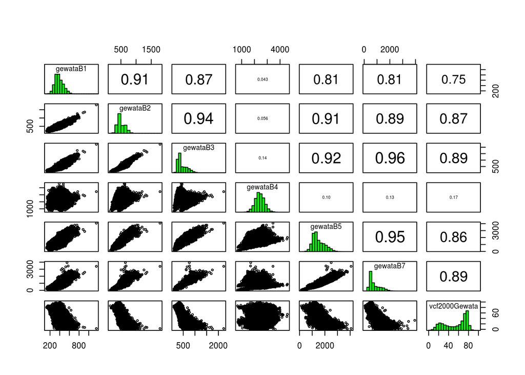

```r
pairs(Gewata)
```

The plot above shows the correlation between the different rasters. The higher the correlation coefficient the more similar the data is they contain. For the VCF it seems that band 3 and 7 show the highest correlation with the VCF, and band 4 is not showing any correlation at all. This means that when trying to predict the tree cover based on these bands all but band 4 are usefull.

Create the correlation model and test whether the above mentioned statement is true.

```r
correlationModel <- lm(vcf2000Gewata ~ gewataB1+ gewataB2 + gewataB3 + gewataB4 + gewataB5 + gewataB7, data = GewataValues)
summary(correlationModel)
```

```
##
## Call:
## lm(formula = vcf2000Gewata ~ gewataB1 + gewataB2 + gewataB3 +
##     gewataB4 + gewataB5 + gewataB7, data = GewataValues)
##
## Residuals:
##     Min      1Q  Median      3Q     Max
## -58.205  -4.636   0.715   5.211 258.436
##
## Coefficients:
##               Estimate Std. Error  t value Pr(>|t|)
## (Intercept)  8.549e+01  5.723e-02 1493.805   <2e-16 ***
## gewataB1     9.291e-02  1.889e-04  491.817   <2e-16 ***
## gewataB2    -1.505e-01  2.353e-04 -639.622   <2e-16 ***
## gewataB3    -2.528e-03  1.698e-04  -14.889   <2e-16 ***
## gewataB4     1.661e-02  2.790e-05  595.378   <2e-16 ***
## gewataB5    -2.006e-02  7.036e-05 -285.119   <2e-16 ***
## gewataB7     2.549e-05  8.969e-05    0.284    0.776
## ---
## Signif. codes:  0 '***' 0.001 '**' 0.01 '*' 0.05 '.' 0.1 ' ' 1
##
## Residual standard error: 8.606 on 1808277 degrees of freedom
##   (13712 observations deleted due to missingness)
## Multiple R-squared:  0.8582, Adjusted R-squared:  0.8582
## F-statistic: 1.824e+06 on 6 and 1808277 DF,  p-value: < 2.2e-16
```

In the summary above the Pr (Probability) value determines whether the band has a predictive value for the model. The lower the Pr the better the band is to predict the tree cover. This means that all bands except band 7 have predictive value for the tree cover.

## Predicted tree cover raster and comparison

Create the predicted tree cover raster based on the correlation model and convert it to a data frame.

```r
predictTreeC <- predict(GewataBands, model=correlationModel, na.rm=TRUE)
predictTreeC[predictTreeC < 0] <- NA
predictTreeCdf <- as.data.frame(getValues(predictTreeC))
```

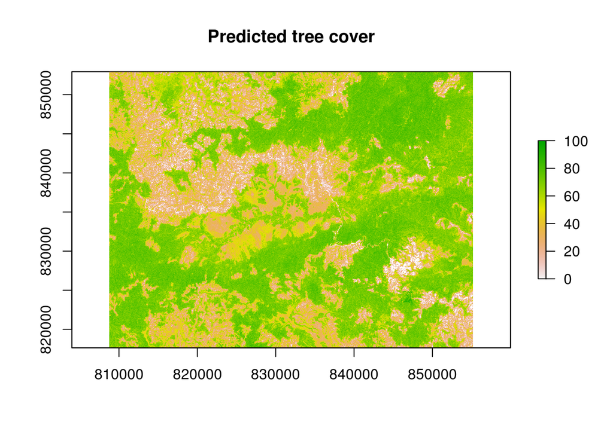

Compare the predicted tree cover raster to the VCF raster.

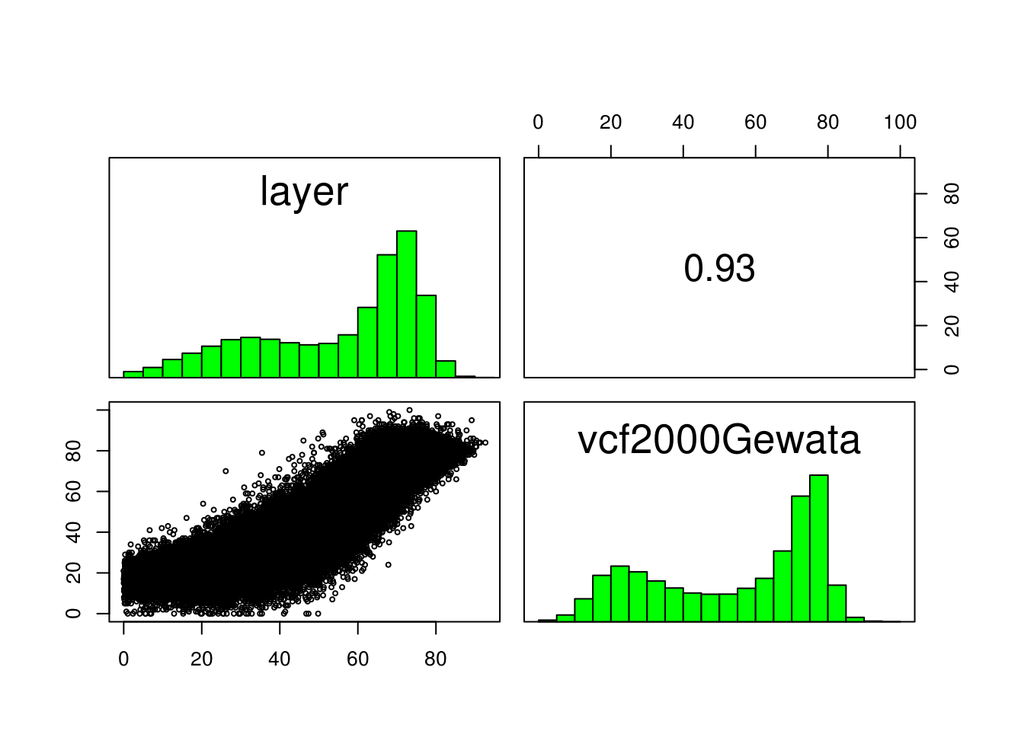

```r
pairs(brick(predictTreeC, vcfGewata))
```

The plot above shows a very high correlation which means the model fits the actual raster pretty well.

## Root Mean Squared Error

Calculate the RMSE (root mean squared error) to compare the predicted tree cover raster to VCF raster.

```r
RMSE <- (sqrt(mean((GewataValues$vcf2000Gewata-predictTreeCdf)^2, na.rm = T)))
```

```
## [1] 8.356825
```

## Training classes comparison

Calculate the NDVI required for the training classes comparison.

```r
ndvi <- overlay(GewataB3, GewataB4, fun=function(x,y){(y-x)/(x+y)})
```

Make trainingPoly classes integers.

```r
trainingPoly@data$Code <- as.numeric(trainingPoly@data$Class)
```

Create the classes raster.

```r
classes <- rasterize(trainingPoly, ndvi, field='Code')
```

```
## Found 16 region(s) and 16 polygon(s)
```

Calculate the RMSE for each class.

```r
difference <- (vcfGewata-predictTreeC)^2
TreeCovDif <- zonal(difference, classes)
RMSEclasses <- (sqrt(TreeCovDif[,2]))
```

```
## [1]  8.865262  4.987001 11.913414
```

The RMSE for the classes shows that the model predicts the tree cover best for forest (RMSE=4.99) and the worst for wetland (RMSE=11.91).